# About Me

Mary Dixon

# Who I am and where I came from

Hello! I’m Mary. I’m from Florida. I’ve always been fascinated with nature, and have worked in various plant nurseries and horticulture labs since I was a teen. After getting my MSc, I was an ag extension agent for the state of Alabama. I moved out to Colorado a couple years ago and love it here (but am still getting used to the snow).

My favorite activities:

1. Painting
2. Playing piano
3. Walk my dog
4. Reading

**My sweet dog is getting old, so sometimes walking him, I’ll actually put him in a stroller like this:**

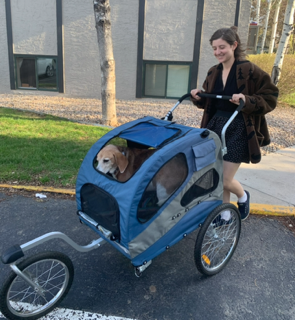

Buddy going for a stroll.

# Research Interests

I’m a PhD candidate in [Jorge Vivanco’s lab](https://agsci.colostate.edu/crb/). We research root and rhizosphere biology and ecology. My specific research focuses on how crop domestication and subsequent breeding events shift the strategies plants employ to recover nutrients (specifically phosphorus) from soil.

## Influential papers

Right before I began my masters degree, I read the breakthrough paper in phosphorus research, “The story of phosphorus: Global food security and food for thought” (Cordell, Drangert, and White 2009). Here, Cordell et al. outline that global reserves of rock phosphate, from which the phosphorus in fertilizers are mined, is finite. Further, at the current rates of use, the limited supplies remaining for this essential nutrient are not sufficient to sustain life.

Recently, I have been coming back to an article that investigates the divergence of the soil microbiome communities and functions between wild and domesticated beans (Pérez-Jaramillo et al. 2017). This research is headed by Juan Perez-Jaramillo, a leader in the world of wild crop microbiome research (Pérez-Jaramillo, Mendes, and Raaijmakers (2016) Pérez-Jaramillo et al. (2018), Pérez-Jaramillo et al. (2019)).

## The mathematics behind my research

As part of my research, I screen many accessions of wild, heirloom, and modern vegetables to understand their differences in phosphorus acquisition. However, because wild varieties are often smaller by nature, it is not valid to compare the raw biomass accumulation of wild to modern accessions. Thus, to accurately compare the effects of low-P stress on my crops, I use a simple calculation to compare the relative effects on my samples.

where “DM<sub>L</sub> dry mass in the unfertilized treatment, and “DM<sub>H</sub>” is dry mass in the fertilized treatment.

We also approximate microbial biomass through qPCR reads:

$$GeneCPS= \sum_{i=1}^{n_o} \frac{n_i}{N} \cdot \frac{GeneCPGi}{16SCPGi}
\cdot 16SCPGs$$
where Gene.CPS = functional gene copies g-1 soil FW, Sobs = number of observed Amplicon Sequence Variants (ASV), ni = number of sequenced reads in ASV i, N = number of sequenced reads, Gene.CPGi = functional gene copies per genome for ASV i, 16S.CPGi = 16S rRNA copies per genome for ASV i, 16S.CPS = 16S rRNA copies g-1 soil FW.

## My computing experience

I am familiar with R/RStudio. I have limited experience with functions and for loops, but for non-iterative work, I am comfortable working with R.

Here is an example of some code I wrote recently that shows how to plot a dbRDA and evalute significance in b-diversity:

```r
ord <- capscale(dist ~ Fertilization + Domestication/Variety + Fertilization*Domestication/Variety + Variety, data=d)
sppscores(ord) <- data

adonis2(dist ~ Fertilization + Domestication/Variety + Fertilization*Domestication/Variety + Variety, data=d, perm=999, by="terms")
pair.mod<-pairwise.adonis(dist,factors=d$Variety, p.adjust.m = "fdr")
pair.mod

ev <- eigenvals(ord)
Axis1_exp = round(ev[1] / sum(ev) * 100, 1)
Axis2_exp = round(ev[2] / sum(ev) * 100, 1)
axes <- as.data.frame(vegan::scores(ord, display="sites", choices=c(1:2)))
names(axes) <- c("Axis1", "Axis2")
axes <- cbind(d, axes)

axes$Variety <- factor(axes$Variety,level = c('LA0716', 'LA1519', 'LA1580','LA1698','B Pink', 'Marglobe', 'Matchless', 'Rutgers', 'Bobcat', 'Quali T','Line 1','Line 2'))

p<-ggplot(data=axes, aes(x=Axis1, y=Axis2, fill=Variety, shape=Domestication)) +
  geom_point(size=6) +
  stat_ellipse(aes(group=Fertilization, color = Fertilization))+
  scale_fill_brewer(palette = 'Paired')+
  scale_color_manual(values = c('black','grey44'))+
  scale_shape_manual(values=c(21,22,23)) +
  guides(fill = guide_legend(
    override.aes=list(shape = rep(21,2)))) +
  labs(x=paste0('CAP1 (', Axis1_exp, '%)'),
       y=paste0('CAP2 (', Axis2_exp, '%)')) +
   theme(axis.text=element_text(size=18, colour = "black"),
        axis.title=element_text(size=32,face="bold"),
        axis.line = element_line(colour = "black"),
        panel.grid.major = element_blank(),
        panel.grid.minor = element_blank(),
        panel.border = element_blank(),
        panel.background = element_blank(),
        legend.key = element_blank(),
        legend.text = element_text(size = 24),
        legend.title = element_text(size = 24, face = 'bold'));p
ggsave(plot=p, filename = 'Data/Outputs/Figures/SuppFigure1.pdf', width = 14, height = 10)
```

I have no experience in any other language, so here is a line for python that I pulled from [this website](https://www.programiz.com/python-programming/examples/hello-world).

```r
print('Hello, world!')
```

## What I hope to get out of this class

Here is what I hope to gain from BZ562:

- Understand how to manage raw sequencing files.
- Learn how to use Alpine.
- Begin to understand how to start genomic analysis.

# Evaluating some R code

This graph shows public data about water discharge at a site along the Poudre river.

```r
library(dataRetrieval)
library(dygraphs)
library(xts)
library(tidyverse)
q <- readNWISdv(siteNumbers = '06752260',
                parameterCd = '00060',
                startDate = '2017-01-01',
                endDate = '2022-01-01') %>%
  rename(q = 'X_00060_00003')

q_xts <- xts(q$q, order.by = q$Date)


dygraph(q_xts, main = "Interactive Water Discharge Graph") %>%
  dyAxis("y", label = "Discharge (cfs)")%>% dySeries("V1", strokeWidth = 2, strokePattern = "dashed")
```

[interactive chart not shown]

# Citations

Cordell, Dana, Jan-Olof Drangert, and Stuart White. 2009. “The Story of Phosphorus: Global Food Security and Food for Thought.” *Global Environmental Change* 19 (2): 292–305.

Pérez-Jaramillo, Juan E, Vı́ctor J Carrión, Mirte Bosse, Luiz FV Ferrão, Mattias De Hollander, Antonio AF Garcia, Camilo A Ramı́rez, Rodrigo Mendes, and Jos M Raaijmakers. 2017. “Linking Rhizosphere Microbiome Composition of Wild and Domesticated Phaseolus Vulgaris to Genotypic and Root Phenotypic Traits.” *The ISME Journal* 11 (10): 2244–57.

Pérez-Jaramillo, Juan E, Vı́ctor J Carrión, Mattias de Hollander, and Jos M Raaijmakers. 2018. “The Wild Side of Plant Microbiomes.” *Microbiome* 6: 1–6.

Pérez-Jaramillo, Juan E, Mattias De Hollander, Camilo A Ramı́rez, Rodrigo Mendes, Jos M Raaijmakers, and Vı́ctor J Carrión. 2019. “Deciphering Rhizosphere Microbiome Assembly of Wild and Modern Common Bean (Phaseolus Vulgaris) in Native and Agricultural Soils from Colombia.” *Microbiome* 7 (1): 1–16.

Pérez-Jaramillo, Juan E, Rodrigo Mendes, and Jos M Raaijmakers. 2016. “Impact of Plant Domestication on Rhizosphere Microbiome Assembly and Functions.” *Plant Molecular Biology* 90: 635–44.